# Project 3 Report

Tim Cook, Alex Poplawski, and T.J. Seislove

4/21/2026

# 2024 NHL Playoff Teams

**Report By: Tim Cook, Alex Poplawski, and T.J. Seislove**

### Introduction

The datasets for this project are team statistics for the 2024 NHL regular season and playoffs.

The first dataset contains playoff stats for the 16 teams that made the playoffs. The recorded stats are games played, wins, losses, ties (all 0 because there are no ties in the playoffs), overtime wins, overtime losses, win-loss percentage, goals scored, goals against, and goal differential.

The second dataset contains the regular season stats for all 32 NHL teams, but we’re only interested in the 16 that made the playoffs. It shares many statistical categories with the playoffs data, but there are few that are only in the playoffs set.

Overtime wins are not counted in the regular season, because that doesn’t matter for the NHL points system. Teams get 2 points for any win, 1 point for an OT loss, and 0 for a regulation loss. Goal differential is also missing in the regular season stats, but there’s no clear reason why.

While the playoffs track win-loss percentage, the regular season tracks points percentage. The number of points a team gets (using the above points system) is divided by the possible 164 points attainable in an 82 game season.

The regular season dataset also tracks statistics regarding shutouts, powerplays, and shot numbers, which the playoffs dataset does not.

**Dataset Links**

[Playoffs](https://www.hockey-reference.com/playoffs/NHL_2024.html)

[Regular Season](https://www.hockey-reference.com/leagues/NHL_2024.html)

### Excel Data Import

```r
nhlreg <- read_excel("2024_NHL_regular.xlsx", skip = 1)
nhlpost <- read_excel("2024_NHL_playoffs.xlsx")
clean_names <- function(x) {str_remove(x, "\\*")}
nhlreg <- nhlreg %>% mutate(Team = clean_names(Team))
nhlcomb <- left_join(nhlpost, nhlreg, by = "Team", suffix = c("_playoffs", "_regular"))
```

# =================

# Exploratory Data Analysis

# =================

##### a) Variable Exploration

##### Distribution of Regular Season Scoring

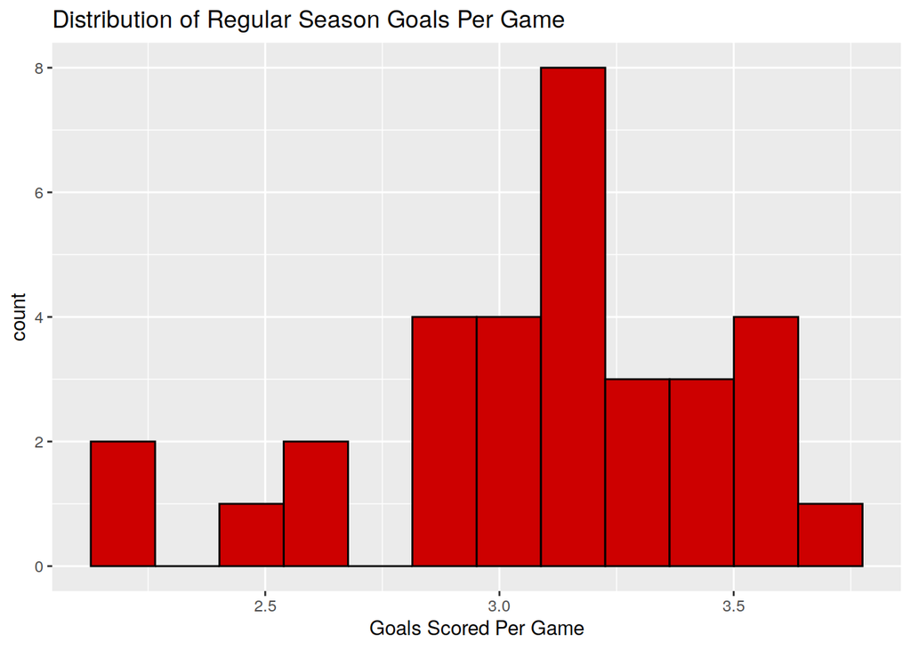

```r
ggplot(nhlreg, aes(x = `GF/G`)) + geom_histogram(bins = 12, fill = "red3", color = "black") +
    labs(title = "Distribution of Regular Season Goals Per Game", x = "Goals Scored Per Game")
```

```r
kable(nhlreg %>%
    summarize(Mean = mean(`GF/G`), SD = sd(`GF/G`), Median = median(`GF/G`)), caption = "Regular Season Scoring Summary")
```

Regular Season Scoring Summary

| Mean | SD | Median |
| --- | --- | --- |
| 3.081875 | 0.3789837 | 3.1 |

##### Distribution of Playoff Win Percentage

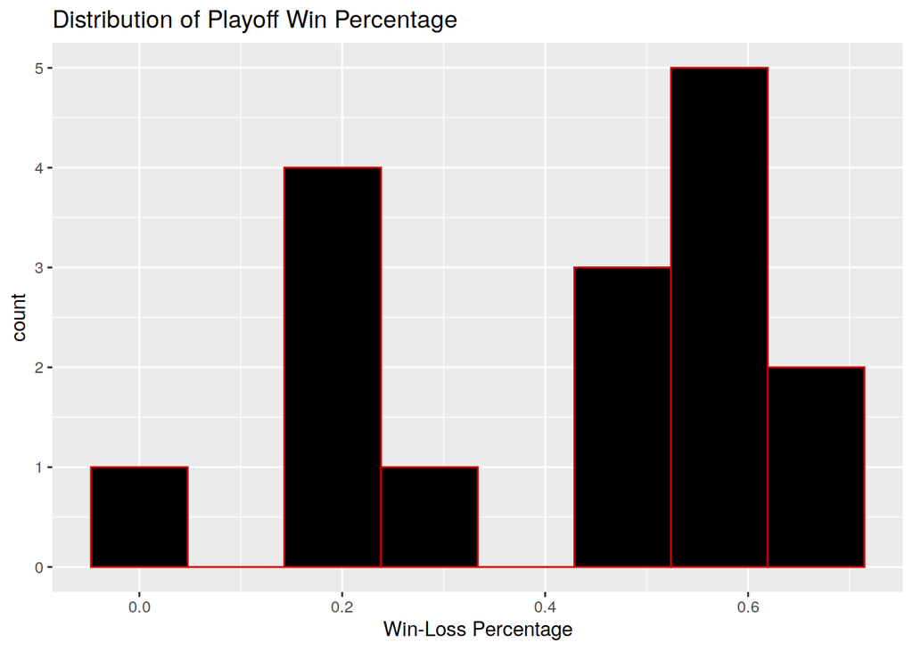

```r
ggplot(nhlpost, aes(x = `W-L%`)) + geom_histogram(bins = 8, fill = "black", color = "red3") +
    labs(title = "Distribution of Playoff Win Percentage", x = "Win-Loss Percentage",
        x = "Win-Loss %")
```

```r
kable(nhlpost %>%
    summarize(Mean = mean(`W-L%`), SD = sd(`W-L%`), Median = median(`W-L%`)), caption = "Post Season Win % Summary")
```

Post Season Win % Summary

| Mean | SD | Median |
| --- | --- | --- |
| 0.4061875 | 0.1946427 | 0.4455 |

##### b) Primary & Foreign Keys

Primary Key (Regular Season): Team. In the raw file, teams that made it to the playoffs had asterisks that I cleaned using str_remove to create the “Foreign Key.” #Primary Key (Playoffs): Team. These were the 16 teams that made it to the playoffs. #Compatability: By joining the two datasets based on Team, we can compare how the team did between the two facets of the season.

# =================

# Research Solutions

# =================

##### Research Question

We want to see if the team(s) that are super dominant in the regular season is just a trap when the playoffs roll around. So we want to see how strongly does a teams regular season points percentage predict their post season win percentage? We’re asking this because there is the ever going debate about if “regular season teams” (Dallas Cowboys in the NFL) struggle when the games become more decisive in the playoffs. We will use a linear model to see if the regular season standings actually matter once the playoffs begin.

##### Analysis and Results

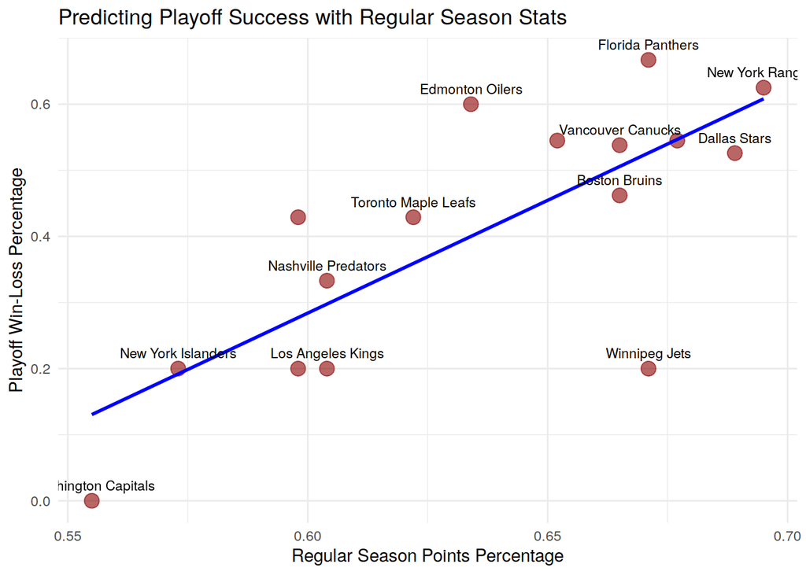

```r
ggplot(nhlcomb, aes(x = `PTS%`, y = `W-L%`)) + geom_point(size = 4, color = "darkred",
    alpha = 0.6) + geom_smooth(method = "lm", color = "blue", se = FALSE) + geom_text(aes(label = Team),
    check_overlap = TRUE, vjust = -1, size = 3) + labs(title = "Predicting Playoff Success with Regular Season Stats",
    x = "Regular Season Points Percentage", y = "Playoff Win-Loss Percentage") +
    theme_minimal()
```

```r
kable(cor(nhlcomb$`PTS%`, nhlcomb$`W-L%`, use = "complete.obs"))
```

| x |
| --- |
| 0.7576796 |

Based on the results of our graph, it seems like there is a very strong correlation between Regular Season Success & Playoff Success.

### Conclusion

Through our data exploration, we found the distribution of goals per game in the regular season, the distribution of playoff win percentage, and the relationship between regular season points and post season win percentages.

The distribution of win percentage in the playoffs has two noticable peaks. One around 0.2, and another around 0.6. This makes sense because some teams have to win more than they lose in order to advance, while others lose more and get eliminated.

Finally, our analysis of playoff win percentage vs regular season points percentage yielded the expected results for the most part. The teams who performed better in the regular season also tended to do better in the playoffs. Notable exceptions are the Panthers and Oilers, who over-performed in the playoffs, and the Jets and Capitals, who under-performed. It’s worth noting that the Capitals got swept in the first round, thus have a win percentage of 0 in the playoffs.